# Vektorski podaci: R paket sf

## Učitavanje prostornih podataka u sf klase

Različiti tipovi/formati prostornih podataka su podržani u okviru **`sf`** paketa, posredstvom **`gdal`** biblioteke:

```r
st_drivers(what = "vector")
```

```
                         name
MEM                       MEM
PCIDSK                 PCIDSK
netCDF                 netCDF
PDS4                     PDS4
VICAR                   VICAR
JP2OpenJPEG       JP2OpenJPEG
PDF                       PDF
MBTiles               MBTiles
BAG                       BAG
EEDA                     EEDA
OGCAPI                 OGCAPI
GDALG                   GDALG
ESRI Shapefile ESRI Shapefile
MapInfo File     MapInfo File
LVBAG                   LVBAG
S57                       S57
DGN                       DGN
OGR_VRT               OGR_VRT
CSV                       CSV
GML                       GML
GPX                       GPX
KML                       KML
GeoJSON               GeoJSON
GeoJSONSeq         GeoJSONSeq
ESRIJSON             ESRIJSON
TopoJSON             TopoJSON
OGR_GMT               OGR_GMT
GPKG                     GPKG
SQLite                 SQLite
ODBC                     ODBC
WAsP                     WAsP
PGeo                     PGeo
MSSQLSpatial     MSSQLSpatial
PostgreSQL         PostgreSQL
MySQL                   MySQL
OpenFileGDB       OpenFileGDB
DXF                       DXF
CAD                       CAD
FlatGeobuf         FlatGeobuf
```

[output cut: 167 more lines]

```
PLSCENES            TRUE      TRUE FALSE
CSW                FALSE      TRUE FALSE
VDV                FALSE      TRUE  TRUE
MVT                FALSE      TRUE  TRUE
NGW                 TRUE      TRUE FALSE
MapML              FALSE      TRUE  TRUE
GTFS               FALSE      TRUE  TRUE
PMTiles            FALSE      TRUE  TRUE
JSONFG             FALSE      TRUE  TRUE
MiraMonVector      FALSE      TRUE  TRUE
ADBC               FALSE      TRUE FALSE
AVCBin             FALSE      TRUE  TRUE
AVCE00             FALSE      TRUE  TRUE
AIVector           FALSE      TRUE FALSE
HTTP                TRUE      TRUE FALSE
```

## Srbija sa granicama autonomnih pokrajina koji je dat u okviru čitanje iz GIS fajla

```r
srbija <- sf::st_read( "data/RAP.shp")
```

## Dimenzije i klasa

```r
dim(srbija)
```

```
[1] 3 7
```

```r
class(srbija)
```

```
[1] "sf"         "data.frame"
```

## plot sf objekta

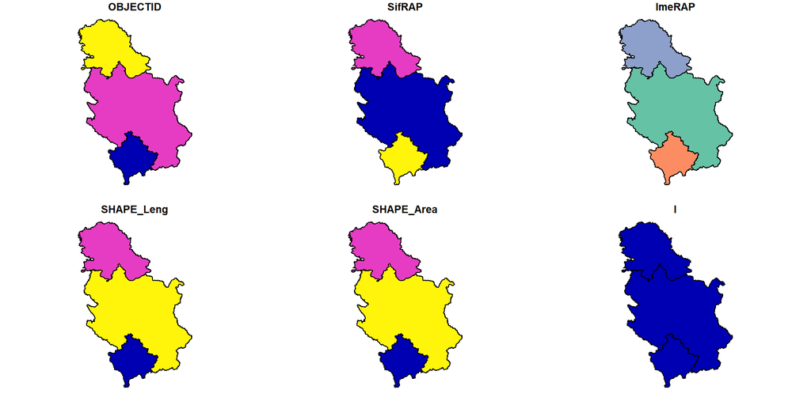

```r
plot(srbija)
```

## Manipulacija **`sf`** objektima

```r
methods(class="sf")
```

```
  [1] $<-                          [
  [3] [[<-                         [<-
  [5] aggregate                    anti_join
  [7] arrange                      as.data.frame
  [9] cbind                        coerce
 [11] dbDataType                   dbWriteTable
 [13] distinct                     dplyr_reconstruct
 [15] drop_na                      duplicated
 [17] filter                       full_join
 [19] gather                       group_by
 [21] group_split                  identify
 [23] initialize                   inner_join
 [25] left_join                    merge
 [27] mutate                       nest
 [29] pivot_longer                 pivot_wider
```

[output cut: 44 more lines]

## Manipulacija **`sf`** objektima

```r
srbija
```

```
Simple feature collection with 3 features and 6 fields
Geometry type: POLYGON
Dimension:     XY
Bounding box:  xmin: 332049.4 ymin: 4633470 xmax: 663034.2 ymax: 5116035
Projected CRS: WGS 84 / UTM zone 34N
  OBJECTID SifRAP            ImeRAP SHAPE_Leng  SHAPE_Area I
1        1      9 Kosovo i Metohija   719739.7 10892519039 1
2        2      7  Centralna Srbija  1950257.8 55974052295 1
3        3      8         Vojvodina  1158156.6 21525723338 1
                        geometry
1 POLYGON ((548473.6 4678936,...
2 POLYGON ((528287.9 4963217,...
3 POLYGON ((528287.9 4963217,...
```

## Manipulacija **`sf`** objektima

```r
srbija[2, ] # izdvojamo samo drugi entitet
```

```
Simple feature collection with 1 feature and 6 fields
Geometry type: POLYGON
Dimension:     XY
Bounding box:  xmin: 348832.6 ymin: 4675726 xmax: 663034.2 ymax: 4993905
Projected CRS: WGS 84 / UTM zone 34N
  OBJECTID SifRAP           ImeRAP SHAPE_Leng  SHAPE_Area I
2        2      7 Centralna Srbija    1950258 55974052295 1
                        geometry
2 POLYGON ((528287.9 4963217,...
```

```r
srbija[, 5] # svi entiteti/redovi a samo jedan atribut/kolona SHAPE_Area
```

```
Simple feature collection with 3 features and 1 field
Geometry type: POLYGON
Dimension:     XY
Bounding box:  xmin: 332049.4 ymin: 4633470 xmax: 663034.2 ymax: 5116035
Projected CRS: WGS 84 / UTM zone 34N
   SHAPE_Area                       geometry
1 10892519039 POLYGON ((548473.6 4678936,...
2 55974052295 POLYGON ((528287.9 4963217,...
3 21525723338 POLYGON ((528287.9 4963217,...
```

```r
srbija["SHAPE_Area"] # svi entiteti/redovi a samo jedan atribut/kolona SHAPE_Area
```

```
Simple feature collection with 3 features and 1 field
Geometry type: POLYGON
Dimension:     XY
Bounding box:  xmin: 332049.4 ymin: 4633470 xmax: 663034.2 ymax: 5116035
Projected CRS: WGS 84 / UTM zone 34N
   SHAPE_Area                       geometry
1 10892519039 POLYGON ((548473.6 4678936,...
2 55974052295 POLYGON ((528287.9 4963217,...
3 21525723338 POLYGON ((528287.9 4963217,...
```

## Grafički prikaz, plot po atributu koji je na petom mestu

Ukoliko želimo da prikažemo učitani objekat, to možemo uraditi prostom komandom **`plot`**:

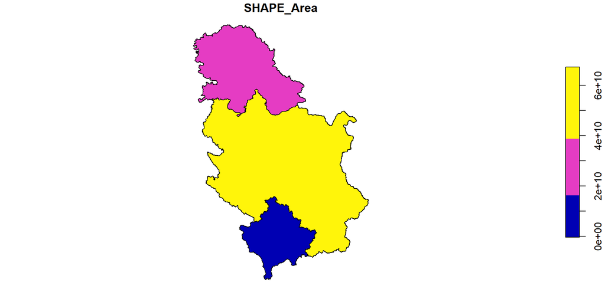

```r
plot(srbija["SHAPE_Area"])
```

## Dodavanje estetike

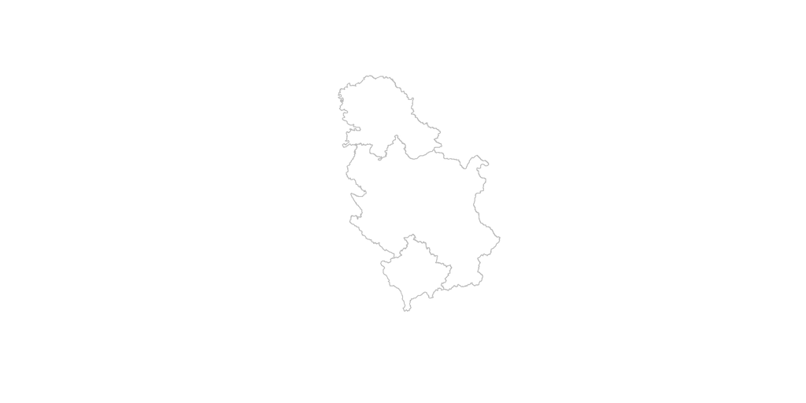

```r
plot(st_geometry(srbija), border = "grey")
```

## Interaktivni prikaz sa **`mapview`**

```r
library(mapview)
mapview(srbija, zcol = "SHAPE_Area", legend = TRUE)
```

[interactive chart not shown]

## 🌍 Koordinatne transformacije sf objekata

**Koordinatne transformacije** omogućavaju prebacivanje prostornih podataka iz jednog **koordinatnog referentnog sistema (CRS)** u drugi.

U `sf` paketu to radimo pomoću funkcije **`st_transform()`**.

### 🔄 **Kako definisati CRS?**

Možemo koristiti **dva standardna načina**:

- 1️⃣ **EPSG kod** → (`4326`) ili
- 2️⃣ **PROJ.4 string** → (`"+proj=longlat +datum=WGS84"`)

```r
# srbija_wgs = st_transform(srbija, crs = "+proj=longlat +datum=WGS84")
srbija_wgs = st_transform(srbija, 4326)
srbija_wgs
```

```
Simple feature collection with 3 features and 6 fields
Geometry type: POLYGON
Dimension:     XY
Bounding box:  xmin: 18.83812 ymin: 41.85251 xmax: 23.00629 ymax: 46.19005
Geodetic CRS:  WGS 84
  OBJECTID SifRAP            ImeRAP SHAPE_Leng  SHAPE_Area I
1        1      9 Kosovo i Metohija   719739.7 10892519039 1
2        2      7  Centralna Srbija  1950257.8 55974052295 1
3        3      8         Vojvodina  1158156.6 21525723338 1
                        geometry
1 POLYGON ((21.58771 42.26112...
2 POLYGON ((21.35781 44.82179...
3 POLYGON ((21.35781 44.82179...
```

## Geometrijske operacije sa sf objektima

Geometrijske operacije nad **vektorskim podacima** u `sf` paketu mogu se podeliti u **tri glavne grupe**, prema vrsti rezultata koji generišu: **numeričke, logičke i prostorne**.

### 🎯 **Zašto koristiti geometrijske operacije u `sf`?**

- ✔ **Omogućavaju prostornu analizu i manipulaciju podacima**.
- ✔ **Pomažu u GIS modeliranju i kartografiji**.
- ✔ **Neophodne su za preklapanje i interakciju slojeva**.

## 📌 **1️⃣ Numeričke operacije** 🔢

Funkcije koje izračunavaju **geometrijske karakteristike objekata**.

- -**Unutar jednog sloja (`sf` objekta)**
- `st_area()` – računa površinu poligona
- `st_length()` – računa dužinu linija
- -**Između više slojeva (`sf` objekata)**
  - `st_distance()` – računa razdaljinu između geometrija

## 📌 **2️⃣ Logičke operacije** ✅

Funkcije koje evaluiraju neki **logički uput** i vraćaju `TRUE`/`FALSE`.

-**Unutar jednog sloja**  
- `st_is_valid()` – proverava da li je geometrija validna

-**Između više slojeva**  
- `st_intersects()` – proverava da li se geometrije preklapaju  
- `st_within()` – proverava da li je jedan objekat potpuno unutar drugog

## 📌 **3️⃣ Prostorne operacije** 🌍

Funkcije koje **kreiraju novu geometriju** na osnovu postojeće.

-**Unutar jednog sloja**  
- `st_centroid()` – kreira centroid poligona  
- `st_buffer()` – kreira buffer zonu oko objekata

-**Između više slojeva**  
- `st_union()` – spaja dve ili više geometrija u jednu  
- `st_intersection()` – kreira novi sloj koji predstavlja presek dva sloja

**Note**

- Obrati pažnju nije ista funkcija `st_intersection()` i `st_intersects()`.
- st_intersects() logički predikat koji vraća TRUE/FALSE (odnosno sparse matricu indeksa) i služi da pita **da li se preklapaju**?
- st_intersection() prostorna operacija koja izračunava i vraća **potpuno novu geometriju** preseka.

## 📏 Numeričke geometrijske operacije

**`sf`** paket omogućava izvođenje **različitih numeričkih operacija** na prostornim objektima, uključujući **izračunavanje dužine, površine, udaljenosti i dimenzije geometrije**.

| **Funkcija** | **Opis** |
| --- | --- |
| `st_length()` | Izračunava **dužinu** linijskih objekata |
| `st_area()` | Izračunava **površinu** poligona |
| `st_distance()` | Izračunava **udaljenost između geometrija** |
| `st_bbox()` | Vraća **bounding box** (minimalni pravougaonik oko geometrije) |
| `st_dimension()` | Vraća **dimenziju geometrije** (0=tačka, 1=linija, 2=poligon) |

## 🎯 **Zašto su ove operacije korisne?**

- ✔ **Pomažu u geometrijskim analizama** – određivanje površine, dužine ili rastojanja između objekata.
- ✔ **Koriste se u GIS aplikacijama** – prostorna analitika i modelovanje.
- ✔ **Neophodne su za prostorne transformacije** – rad sa prostornim podacima i koordinatnim sistemima.

## Numeričke geometrijske operacije - površina

Na primer, možemo izračunati površinu poligona `sf` objekta **srbija**:

```r
srbija$area = st_area(srbija)
srbija$area[1:3]
```

```
Units: [m^2]
[1] 10885979124 55940445913 21512844136
```

Rezultat je klase `units`:

```r
class(srbija$area)
```

```
[1] "units"
```

## Numeričke geometrijske operacije površina jedinice

Jedinice se mogu promeniti sa komandom `set_units` iz paketa `units`

```r
library(units)

srbija$area = set_units(srbija$area, km^2)
srbija$area[1:3]
```

```
Units: [km^2]
[1] 10885.98 55940.45 21512.84
```

```r
srbija$area = as.numeric(srbija$area) # pretvaranje u numerički format (bez jedinica) korisno za plotove i ML, statistiku,...
```

## 🔍 Logičke operacije nad `sf` geometrijom

Ako imamo dva **`sf`** objekta, **`x`** i **`y`**, možemo koristiti **logičke operacije** da proverimo prostorne relacije između njihovih geometrija.  
Svaka funkcija vraća **TRUE/FALSE vrednosti**, pokazujući da li se određeni odnosi javljaju između `feature`-a u okviru `x` i `y`.

| **Funkcija** | **Opis** |
| --- | --- |
| `st_intersects()` | Da li se geometrije **seku**? |
| `st_disjoint()` | Da li su geometrije **potpuno razdvojene**? |
| `st_touches()` | Da li se geometrije **dodiruju, ali se ne preklapaju**? |
| `st_crosses()` | Da li **seku jedna drugu, ali ne potpuno**? |
| `st_within()` | Da li je `x` **unutar** `y`? |
| `st_contains()` | Da li `x` **sadrži** `y`? |
| `st_overlaps()` | Da li `x` i `y` **delimično preklapaju**? |
| `st_covers()` | Da li `x` **pokriva celu geometriju** `y`? |
| `st_covered_by()` | Da li je `x` **potpuno unutar `y`**? |
| `st_equals()` | Da li su `x` i `y` **identični**? |
| `st_equals_exact()` | Da li su `x` i `y` **skoro identični** (uz toleranciju greške)? |

## 🎯 **Zašto su ove logičke operacije korisne?**

- ✔ **Neophodne su za prostorne upite i GIS analize**.
- ✔ **Pomažu u prostornom filtriranju i analizi podataka**.
- ✔ **Omogućavaju kompleksne prostorne relacije između objekata**.

## 🔍 Logičke operacije nad `sf` geometrijom st_intersects

✔ **TRUE** – Dve geometrije imaju **presek**  
✔ **FALSE** – Geometrije su **potpuno razdvojene**

```r
# sparse = FALSE, funkcija vraća logičku (TRUE/FALSE) matricu
srbija_int = st_intersects(srbija, srbija[1,], sparse = FALSE)
srbija_int
```

```
      [,1]
[1,]  TRUE
[2,]  TRUE
[3,] FALSE
```

## 🔍 Logičke operacije nad `sf` geometrijom st_intersects slikovito

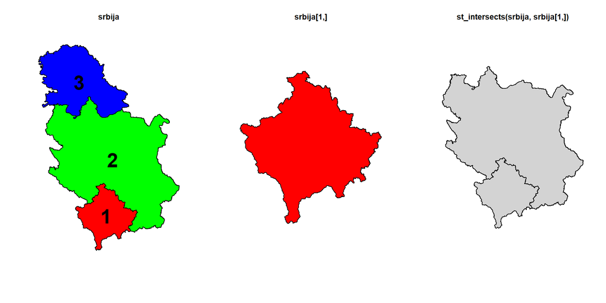

## sf geometrijske operacije

Paket **`sf`** omogućava izvođenje **standardnih geometrijskih operacija** koje kreiraju **novu geometriju**. Ove operacije mogu se primeniti na svaki **feature** u okviru `sf` objekta.

| **Funkcija** | **Opis** |
| --- | --- |
| `st_centroid()` | Računa **centroid** geometrije |
| `st_buffer()` | Kreira **buffer zonu** oko geometrije |
| `st_sample()` | Generiše **nasumične tačke** unutar geometrije |
| `st_convex_hull()` | Kreira **konveksni omotač** geometrije |
| `st_voronoi()` | Kreira **Voronoi dijagram** na osnovu geometrijskih tačaka |

## sf geometrijske operacije slikovito

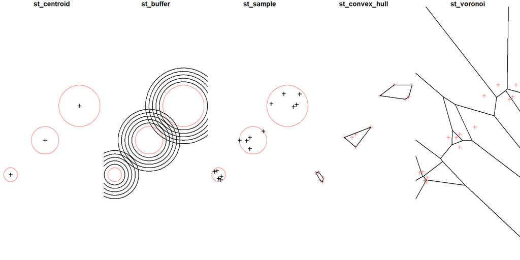

## 🎯 Zašto koristiti sf geometrijske operacije?

- ✔ Omogućavaju prostorne analize i manipulacije geometrijom.
- ✔ Pomažu u pripremi prostornih podataka za analizu.
- ✔ Koriste se u GIS aplikacijama, prostornim modelima …

## 📍 sf geometrijske operacije – primer `st_centroid()`

Funkcija **`st_centroid()`** iz `sf` paketa omogućava izračunavanje **centroida poligona**.  
To su tačke koje predstavljaju **geometrijski centar svakog poligona** u datasetu.

```r
srbija_centroids = st_centroid(srbija)
```

Kartiranje poligona i centroida

```r
plot(
  st_geometry(srbija),
  border = "grey"
)
plot(
  st_geometry(srbija_centroids),
  col = "red", pch = 3,
  add = TRUE
)
```

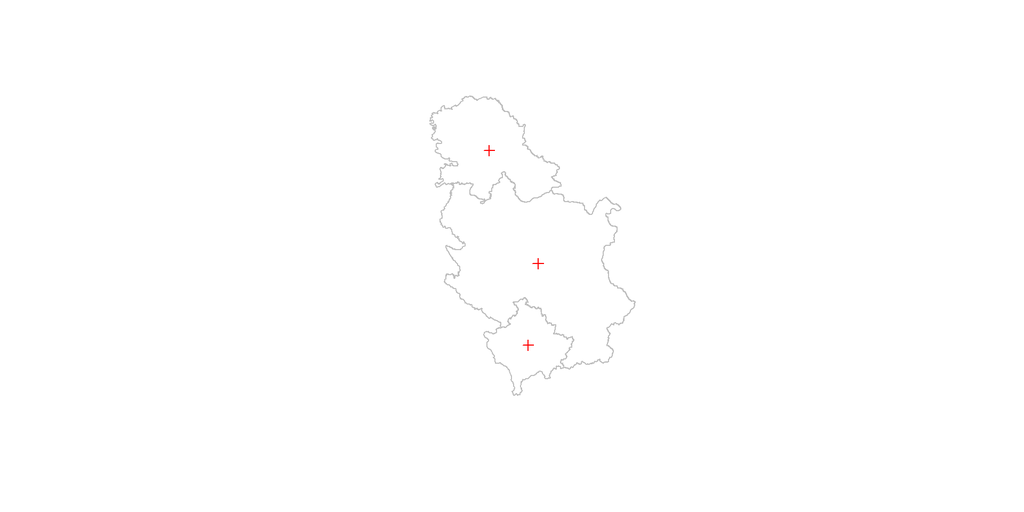

## Primer: **`st_centroid()`** kod plotovanja

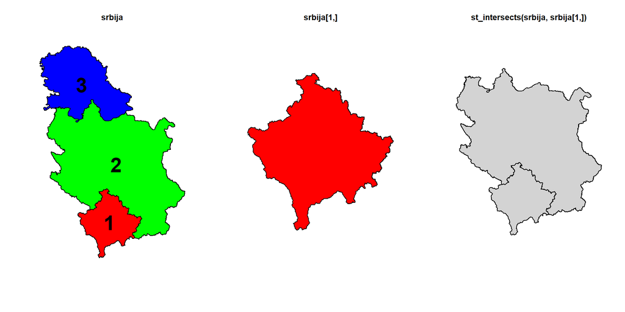

```r
# Prikaz svih geometrija u jednom panelu
srbija_int = st_intersects(srbija, srbija[1,], sparse = FALSE)
# Podešavanje panela za plot u 3 dela gde je grafik podeljen na 1 red i 3 kolone
par(mfrow = c(1,3))  # Podešavanje panela 1x3
plot(srbija$geometry  , main = "srbija", col = c("red","green","blue") )
# Dodavanje oznaka na centroidima
centroidi <- st_centroid(srbija$geometry)  # Izračunavanje centroida
koordinate <- st_coordinates(centroidi)  # Koordinate centroida
# Dodavanje oznaka na centroidima
text(koordinate,
     labels = 1:3,  # Oznake (npr. brojevi 1, 2, 3)
     col = "black",  # Boja teksta
     font = 2,       # Bold tekst
     cex = 3)      # Veličina teksta
plot(srbija[1,]$geometry, main = "srbija[1,]", col = c("red"))
plot(srbija[srbija_int,]$geometry, main = "st_intersects(srbija, srbija[1,])", col="lightgray")
```

## Druge **geometrijske operacije** u sf paketu

Paket **`sf`** omogućava izvođenje **geometrijskih operacija** koje kombinuju ili modifikuju više geometrijskih objekata.  
Ove funkcije su ključne za **prostorne analize, GIS operacije i modeliranje prostornih podataka**.

| **Funkcija** | **Opis** |
| --- | --- |
| `st_intersection()` | Vraća **zajedničku oblast** između geometrija `x` i `y` |
| `st_difference()` | Vraća **oblast iz `x` koja ne pripada `y`** |
| `st_sym_difference()` | Vraća **delove `x` i `y` koji nisu u preseku** |
| `st_union()` | Spaja **dve ili više geometrija u jednu** |

## Druge **geometrijske operacije** u sf slikovito

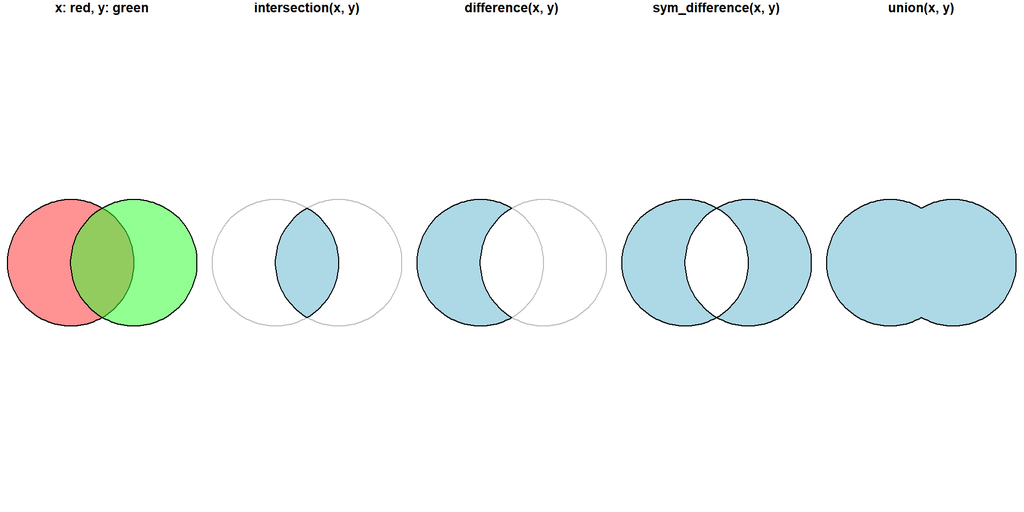

## Primer: `st_centroid()` za kantone Švajcarske

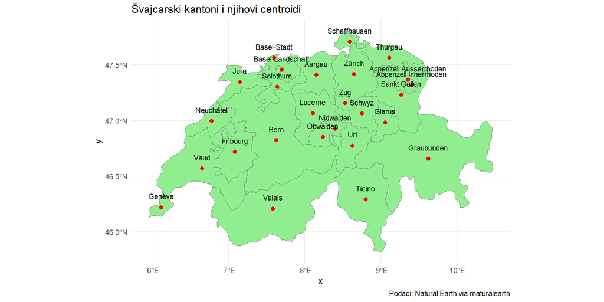

## Primer: `st_centroid()` za kantone Švajcarske kod

```r
library(rnaturalearth)

# Učitavanje država sveta i filtriranje samo Švajcarsku
world <- ne_countries(scale = "medium", returnclass = "sf")
switzerland <- world[world$name == "Switzerland", ]
# Učitavanje administrativnih regiona (kantona) Švajcarske
ch_regions <- ne_states(country = "Switzerland", returnclass = "sf")
# Računanje centroida kantona
ch_centroids <- st_centroid(ch_regions)

# Prikaz karte sa toponimima
ggplot() +
  geom_sf(data = ch_regions, fill = "lightgreen", color = "gray40") +
  geom_sf(data = ch_centroids, color = "red", size = 2) +
  geom_sf_text(data = ch_centroids, aes(label = name), size = 3, nudge_y = 0.02) +
  labs(
    title = "Švajcarski kantoni i njihovi centroidi",
    caption = "Podaci: Natural Earth via rnaturalearth"
  ) +
  theme_minimal()
```

## Kreiranje zone oko Građevinskog fakulteta i preuzimanje prikaz biblioteka iz OSM

[interactive chart not shown]

## Kreiranje zone oko Građevinskog fakulteta i preuzimanje prikaz biblioteka iz OSM kod

```r
library(osmdata)
library(mapview)
# Kreiraj sf tačku za Građevinski fakultet
grf <- st_sf(name = "Građevinski fakultet",
             geometry = st_sfc(st_point(c(20.4761, 44.8058)), crs = 4326))
# Projekcija u metarski CRS (npr. UTM zona 34N)
grf_proj <- st_transform(grf, 32634)
# Napravi buffer od 5 km
buffer_proj <- st_buffer(grf_proj, dist = 5000)
# Vrati nazad u WGS84 za prikaz
buffer <- st_transform(buffer_proj, 4326)
# Preuzmi OSM podatke o bibliotekama u bounding box-u zone
query <- opq(bbox = st_bbox(buffer)) %>%
  add_osm_feature(key = "amenity", value = "library")
osm_libs <- osmdata_sf(query)$osm_points
# Filtriraj biblioteke unutar buffera
libs_in_buffer <- osm_libs[st_within(osm_libs, buffer, sparse = FALSE), ]

# Topo podloga
mapviewOptions(basemaps = "Esri.WorldTopoMap")
# Prikaz: buffer (plava zona), GRF (crna tačka), biblioteke (crvene tačke)
mapview(buffer, col.regions = "lightblue", alpha.regions = 0.3, layer.name = "Zona 5 km") +
  mapview(grf, col.regions = "black", layer.name = "GRF") +
  mapview(libs_in_buffer, col.regions = "red", layer.name = "Biblioteke", label = libs_in_buffer$name)
```

## Prostorne geometrijske operacije

[figure not shown]

Prostorne operacije u sf paketu

## Prostorne geometrijske operacije 2

[figure not shown]

Prostorne operacije u sf paketu

## Mini-projekat: “Prostorna analiza promena šumskog pokrivača 2012-2018”

- Priprema i transformacija podataka: Učitavanje CLC slojeva za 2012 i 2018, izdvajanje šumskih klasa.
- Analiza na lokalnom nivou: Novi Sad i okolina i Bor i okolina.
- Analiza promena kroz vreme: Detekcija krčenja u opštini Bujanovac.

## CLC iz GIS fajla za 2018 i 2012

U ovom slajdu učitavamo CLC (Corine Land Cover) podatke iz GIS fajlova za 2018. i 2012. godinu, koristeći `sf::st_read()`. Ovi slojevi omogućavaju analizu promene zemljišnog pokrova kroz vreme.

```r
clc18 <- sf::st_read("data/CLC18_RS.shp")
clc12 <- sf::st_read("data/CLC12_RS.shp")
names(clc18)
```

```
[1] "ID"         "CODE_18"    "Area_Ha"    "Remark"     "SHAPE_Leng"
[6] "SHAPE_Area" "geometry"
```

## CLC karta sa podrazumevanim bojama

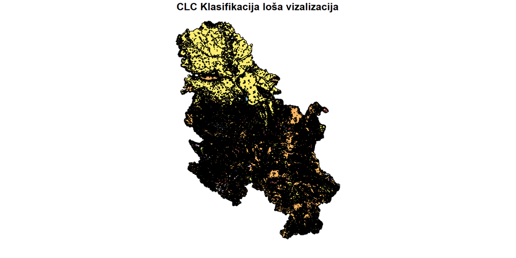

```r
plot(clc18["CODE_18"], main = "CLC Klasifikacija loša vizalizacija")
```

## CLC legenda

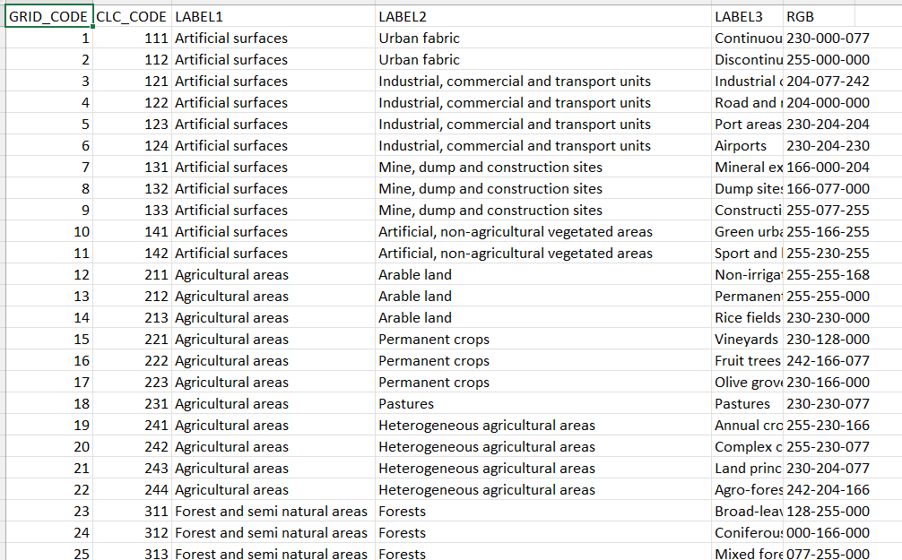

```r
clc_legend <- read_csv("data/clc_legend.csv")
head(clc_legend)
```

```
# A tibble: 6 × 6
  GRID_CODE CLC_CODE LABEL1              LABEL2                     LABEL3 RGB
      <dbl>    <dbl> <chr>               <chr>                      <chr>  <chr>
1         1      111 Artificial surfaces Urban fabric               Conti… 230-…
2         2      112 Artificial surfaces Urban fabric               Disco… 255-…
3         3      121 Artificial surfaces Industrial, commercial an… Indus… 204-…
4         4      122 Artificial surfaces Industrial, commercial an… Road … 204-…
5         5      123 Artificial surfaces Industrial, commercial an… Port … 230-…
6         6      124 Artificial surfaces Industrial, commercial an… Airpo… 230-…
```

## CLC legenda i boje iz RGB u HEX zapis za svaku kategoriju

[output not shown]

```r
clc_legend <- clc_legend |>
  mutate(Color = sapply( RGB, function(rgb_str) {
    # Korak 1: Razdvajanje RGB stringa na komponente
      rgb_vals <- strsplit(rgb_str, "-") |> unlist() |> as.numeric()

    # Korak 2: Konverzija u hex kod (0-255 → 0-1)
    rgb(rgb_vals[1]/255, rgb_vals[2]/255, rgb_vals[3]/255, maxColorValue = 1)
           } # kraj funkcije unutar sapply petlje
    )# zatvaramo sapply
    )# zatcaramo mutate

# Prikaz prvih redova rezultata
head(clc_legend[, c("CLC_CODE", "RGB", "Color")])
```

```
# A tibble: 6 × 3
  CLC_CODE RGB         Color
     <dbl> <chr>       <chr>
1      111 230-000-077 #E6004D
2      112 255-000-000 #FF0000
3      121 204-077-242 #CC4DF2
4      122 204-000-000 #CC0000
5      123 230-204-204 #E6CCCC
6      124 230-204-230 #E6CCE6
```

## Karta sa preporčenim bojama `left_join` lookup tabele i prostornih podataka

Na ovom slajdu spajamo `clc18` sloj sa lookup tabelom `clc_legend` pomoću `left_join()`, kako bismo dodali preporučene boje za vizualizaciju. Prvo proveravamo i usklađujemo tipove podataka između `CODE_18` i `CLC_CODE`, a zatim spajamo prostorne i atributne podatke.

```r
# tip atributa u sf objektu
str(clc18$CODE_18)
```

```
 chr [1:34794] "111" "111" "111" "111" "112" "112" "112" "112" "112" "112" ...
```

```r
# tip atributa u tabeli clc_legend
str(clc_legend$CLC_CODE)
```

```
 num [1:44] 111 112 121 122 123 124 131 132 133 141 ...
```

```r
# Treba ih svesti na isti tip
clc_legend$CLC_CODE <- as.character(clc_legend$CLC_CODE)
# Spajanje `sf_obj` sa lookup tabelom na osnovu CODE_18 i CLC_CODE
clc18 <- left_join(clc18, clc_legend, by = c("CODE_18" = "CLC_CODE"))
# Spajanje `sf_obj` sa lookup tabelom na osnovu CODE_12 i CLC_CODE
clc12 <- left_join(clc12, clc_legend, by = c("CODE_12" = "CLC_CODE"))

clc18[1,]
```

```
Simple feature collection with 1 feature and 12 fields
Geometry type: POLYGON
Dimension:     XY
Bounding box:  xmin: 573174.2 ymin: 4795865 xmax: 574936.5 ymax: 4796781
Projected CRS: ETRS89 / UTM zone 34N
    ID CODE_18  Area_Ha Remark SHAPE_Leng SHAPE_Area GRID_CODE
1 RS_1     111 57.65009   <NA>   6456.549   576500.9         1
               LABEL1       LABEL2                  LABEL3         RGB   Color
1 Artificial surfaces Urban fabric Continuous urban fabric 230-000-077 #E6004D
                        geometry
1 POLYGON ((574615.8 4796652,...
```

## Karta sa preporčenim bojama

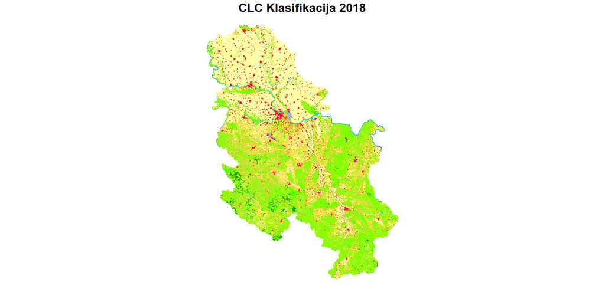

```r
#  Klasični `plot()` sa bojama iz lookup tabele
plot(clc18["CODE_18"], col = clc18$Color, border = NA, main = "CLC Klasifikacija 2018")
```

## Izdvojimo samo šume za Srbiju

Na ovom slajdu izdvajamo samo šumske površine iz CLC slojeva za 2018. i 2012. godinu. Koristimo `filter(str_starts(CODE_18, "31"))` kako bismo selektovali klase `311`, `312` i `313`, koje predstavljaju šumske površine u Corine Land Cover klasifikaciji.

```r
# 311   Forest and semi natural areas   Forests
# 312   Forest and semi natural areas   Forests
# 313   Forest and semi natural areas   Forests
# Filtriranje samo šuma (CODE_18 počinje sa "31")
sume18 <- clc18 |> filter(str_starts(CODE_18, "31"))
sume12 <- clc12 |> filter(str_starts(CODE_12, "31"))
```

## Kod za uporedni prikaz šuma 2018 vs 2012

```r
# Podešavanje rasporeda za dva panela (jedan pored drugog)
par(mfrow = c(1, 2))  # Postavlja raspored grafikona u 1 red i 2 kolone
# Prikaz šuma za 2018. godinu
plot(sume18["CODE_18"], col = sume18$Color, border = NA,
     main = "Šumske površine - 2018", key.pos = NULL, reset = FALSE)
# Prikaz šuma za 2012. godinu
plot(sume12["CODE_12"], col = sume12$Color, border = NA,
     main = "Šumske površine - 2012", key.pos = NULL, reset = FALSE)
```

```r
# Resetovanje podešavanja za grafikon
par(mfrow = c(1, 1))  # Vraća raspored grafikona na podrazumevano stanje (jedan grafik po stranici)
```

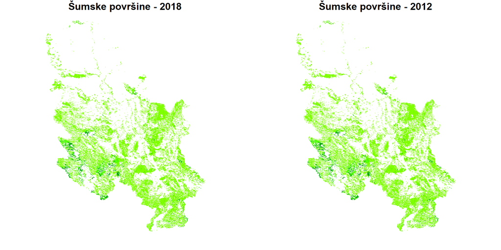

## 🌲 Površine šumskih klasa u Srbiji (CLC 2012 vs 2018)

```r
# Površina svih šuma 2018. u km2
sum_km2_2018 <- sum(units::set_units(st_area(sume18), "km2"))

# Udeo šuma u ukupnoj površini (2018)
proc_2018 <- sum(st_area(sume18)) / sum(st_area(clc18)) * 100

# Površina svih šuma 2012. u km2
sum_km2_2012 <- sum(units::set_units(st_area(sume12), "km2"))

# Udeo šuma u ukupnoj površini (2012)
proc_2012 <- sum(st_area(sume12)) / sum(st_area(clc12)) * 100
```

| Godina | Površina šuma (km²) | Udeo u ukupnoj površini (%) |
| --- | --- | --- |
| 2012 | 23839 | 30.02 |
| 2018 | 23809.2 | 29.99 |

Prema CLC podacima, Srbija je između 2012. i 2018. godine izgubila oko 30 km² šumskih površina.

## Učitajmo granice opština u Srbiji

```r
opst <- sf::st_read("data/Municipalities.gpkg")
opst
```

```
Simple feature collection with 161 features and 3 fields
Geometry type: MULTIPOLYGON
Dimension:     XY
Bounding box:  xmin: 18.80852 ymin: 42.22762 xmax: 22.97898 ymax: 46.1894
Geodetic CRS:  WGS 84
First 10 features:
              Name ind       Area                           geom
1              Bor   0  860008220 MULTIPOLYGON (((21.77246 43...
2          Kladovo   0  674110467 MULTIPOLYGON (((22.64921 44...
3        Majdanpek   0  986712895 MULTIPOLYGON (((22.30399 44...
4          Negotin   0 1149447369 MULTIPOLYGON (((22.46989 44...
5          Golubac   0  465009532 MULTIPOLYGON (((21.49457 44...
6           Kučevo   0  716607581 MULTIPOLYGON (((21.62833 44...
7      Malo Crniće   0  269537722 MULTIPOLYGON (((21.50073 44...
8         Petrovac   0  656111944 MULTIPOLYGON (((21.62833 44...
9        Požarevac   1  494419204 MULTIPOLYGON (((21.2233 44....
10 Veliko Gradište   0  408951048 MULTIPOLYGON (((21.49457 44...
```

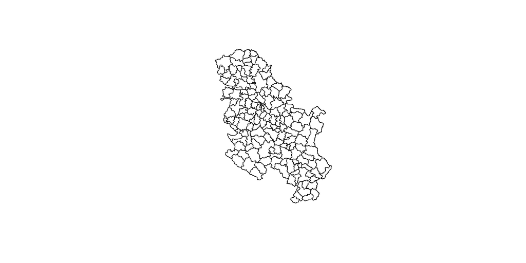

```r
plot(opst$geom)
```

## Karta granica opština u Srbiji

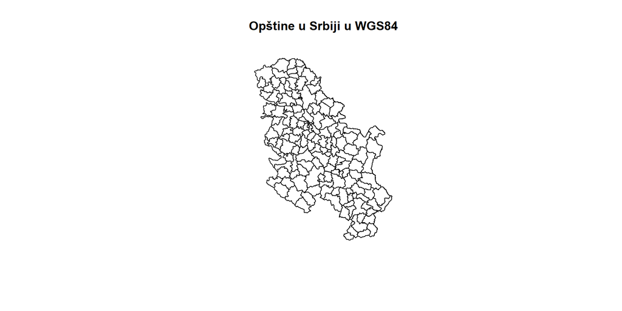

```r
plot(opst$geom, main="Opštine u Srbiji u WGS84")
```

## Karta CLC klasifikacije za Novi Sad

**Ovaj slajd prikazuje CLC klasifikaciju za Novi Sad koristeći `sf` i `plot()` funkciju.**  
Prvo se transformišu podaci u isti **CRS**, zatim se **izdvaja Novi Sad** prostornim presekom (`st_intersection()`),  
a konačno se **prikazuje karta sa bojama** iz lookup tabele (`col = ns$Color`).

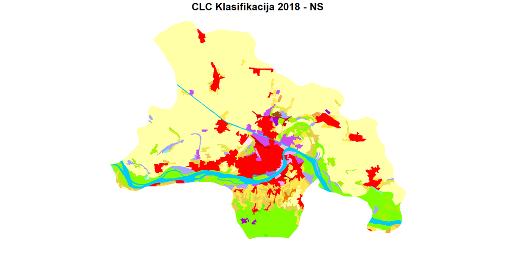

```r
# transformacija podataka u isti CRS
opst <- st_transform(opst, st_crs(clc18) )
# izdvajanje samo NS
ns = st_intersection(opst[opst$Name=="Novi Sad", ], clc18)
#  Klasični `plot()` sa bojama iz lookup tabele
plot(ns["CODE_18"], col = ns$Color, border = NA, main = "CLC Klasifikacija 2018 - NS")
```

## Izdvojmo samo šume u NS

```r
# 311   Forest and semi natural areas   Forests
# 312   Forest and semi natural areas   Forests
# 313   Forest and semi natural areas   Forests
# Filtriranje samo šuma (CODE_18 počinje sa "31")
ns_sume <- ns |> filter(str_starts(CODE_18, "31"))

head(ns_sume)
```

```
Simple feature collection with 6 features and 15 fields
Geometry type: GEOMETRY
Dimension:     XY
Bounding box:  xmin: 388129.4 ymin: 4999791 xmax: 426347.9 ymax: 5008757
Projected CRS: ETRS89 / UTM zone 34N
           Name ind      Area       ID CODE_18     Area_Ha Remark SHAPE_Leng
41.180 Novi Sad   1 728042658 RS_24862     311   366.64847   <NA>  15929.301
41.181 Novi Sad   1 728042658 RS_24879     311    31.47722   <NA>   3442.257
41.182 Novi Sad   1 728042658 RS_24884     311    29.15111   <NA>   4432.015
41.183 Novi Sad   1 728042658 RS_24891     311 20103.19785   <NA> 279850.152
41.184 Novi Sad   1 728042658 RS_24892     311    30.62091   <NA>   3703.281
41.185 Novi Sad   1 728042658 RS_24896     311   145.25431   <NA>   8837.930
        SHAPE_Area GRID_CODE                        LABEL1  LABEL2
41.180   3666484.7        23 Forest and semi natural areas Forests
41.181    314772.2        23 Forest and semi natural areas Forests
41.182    291511.1        23 Forest and semi natural areas Forests
41.183 201031978.5        23 Forest and semi natural areas Forests
41.184    306209.1        23 Forest and semi natural areas Forests
41.185   1452543.1        23 Forest and semi natural areas Forests
                    LABEL3         RGB   Color                           geom
41.180 Broad-leaved forest 128-255-000 #80FF00 POLYGON ((422570.4 5001616,...
41.181 Broad-leaved forest 128-255-000 #80FF00 POLYGON ((405410.4 5005063,...
41.182 Broad-leaved forest 128-255-000 #80FF00 POLYGON ((405560.3 5005525,...
41.183 Broad-leaved forest 128-255-000 #80FF00 MULTIPOLYGON (((413039.9 50...
41.184 Broad-leaved forest 128-255-000 #80FF00 POLYGON ((388410.4 5007823,...
41.185 Broad-leaved forest 128-255-000 #80FF00 POLYGON ((401448.5 5008690,...
```

## Karta samo šumskih klasa u NS

```r
# interaktivna karta mapview
mapview::mapview(ns_sume, zcol = "CODE_18", col.regions = ns_sume$Color, legend = TRUE)
```

[interactive chart not shown]

## Površine šumskih klasa u NS

```r
# Površina svih šuma u opštini NS
sum( st_area (ns_sume ) )
```

```
76198812 [m^2]
```

```r
# Površina u km2
sum( units::set_units(st_area (ns_sume ), "km2" ) )
```

```
76.19881 [km^2]
```

```r
# procenenat od ukupne površine
sum( st_area (ns_sume ) ) / sum( st_area (ns ) ) *100
```

```
10.47235 [1]
```

## Površine šumskih klasa po svim opštinama

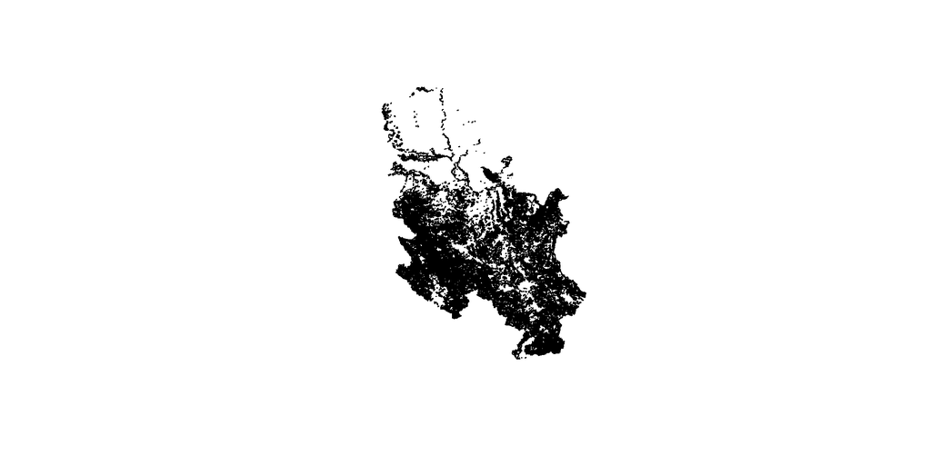

```r
# Površine svih opština
opst$Povrsina_km2 <- set_units(st_area(opst$geom), "km2")
# Prostorni presek - izdvajanje CLC 18 sloja unutar svake opštine
opst_sume18 <- st_intersection( opst, sume18)
# Prostorni presek - izdvajanje CLC 12 sloja unutar svake opštine
opst_sume12 <- st_intersection( opst, sume12)
# plot
plot(opst_sume18$geom)
```

## Poređenje površina šuma u jednoj opštini (Bor) za 2018. i 2012

```r
# Površine za jednu opštinu
bp = opst[opst$Name=="Bor",]$Povrsina_km2
# Za 2018
bps18= sum(set_units(st_area(opst_sume18[opst_sume18$Name=="Bor",]$geom), "km2") )
bpp18=bps18/bp # Procenat šuma u ukupnoj površini
# Za 2012
bps12= sum(set_units(st_area(opst_sume12[opst_sume12$Name=="Bor",]$geom), "km2") )
bpp12=bps12/bp # Procenat šuma u ukupnoj površini

paste("Površina Bor:", round(bp), "km²",
      "Šume 2018:", round(bps18), "km²", "(", round(bpp18,1), "%)",
      "Šume 2012:", round(bps12), "km²", "(", round(bpp12,1), "%)")
```

```
[1] "Površina Bor: 859 km² Šume 2018: 312 km² ( 0.4 %) Šume 2012: 313 km² ( 0.4 %)"
```

## Poređenje površina šuma u jednoj opštini (Bor) za 2018. i 2012

```r
bor18 = opst_sume18[opst_sume18$Name=="Bor",]
bor12 = opst_sume12[opst_sume12$Name=="Bor",]
# Pronalazak nestalih šuma (bile prisutne 2012, ali ih nema 2018)
sume_nestale = st_difference(bor12$geom,st_union(bor18$geom))
# Pronalazak novih šuma (bile prisutne 2018, ali ih nije bilo 2012)
sume_nove <- st_difference(bor18$geom, st_union(bor12$geom) )
par(mfrow = c(1,2))
#  Prikaz izgubljenih šuma (2012 - 2018)
plot(sume_nestale, col = "red", main = "Nestale šume (2012 - 2018)"  ,key.pos = NULL, reset = FALSE)
# Prikaz novih šuma (2012 - 2018)
plot(sume_nove, col = "green", main = "Nove šume (2012 - 2018)"  , key.pos = NULL, reset = FALSE)
```

```r
# Resetovanje podešavanja za grafikon
par(mfrow = c(1,1))
```

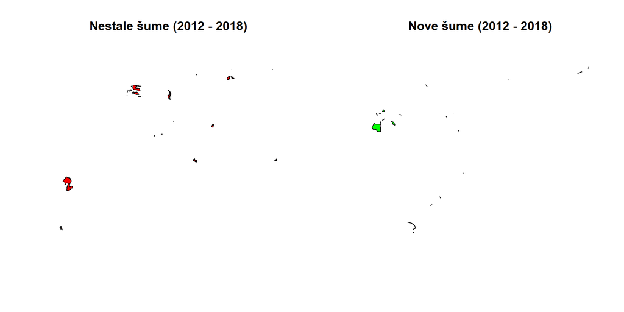

## Nestale šume u Bujanovcu od 2012 do 2018

```r
bj18 = opst_sume18[opst_sume18$Name=="Bujanovac",]
bj12 = opst_sume12[opst_sume12$Name=="Bujanovac",]
# Pronalazak nestalih šuma (bile prisutne 2012, ali ih nema 2018)
sume_nestale = st_difference(bj12,st_union(bj18$geom))

mapview::mapview(sume_nestale)
```

[interactive chart not shown]

## Površine šumskih klasa po svim opštinama prvi način

```r
opst$s18 = 0 ; opst$s12 = 0 ; opst$p18 = 0 ; opst$p12 = 0

for (i in 1:nrow(opst)) {
  p = opst[i, ]$Povrsina_km2  # Ukupna površina opštine
  # Provera da li ima šume u opštini 2018, Vračar nema npr
  match_18 = opst_sume18[opst_sume18$Name == opst[i, ]$Name, ]
  if (nrow(match_18) > 0) {  # Ako ima šume
    s18 = sum(set_units(st_area(match_18$geom), "km2"))  # Površina šuma 2018
    p18 = as.numeric(s18 / p)*100  # Procenat šuma 2018
    opst$s18[i] = s18
    opst$p18[i] = p18
  }
  # Provera da li ima šume u opštini 2012, Vračar nema npr
  match_12 = opst_sume12[opst_sume12$Name == opst[i, ]$Name, ]
  if (nrow(match_12) > 0) {  # Ako ima šume
    s12 = sum(set_units(st_area(match_12$geom), "km2"))  # Površina šuma 2012
    p12 = as.numeric(s12 / p)*100  # Procenat šuma 2012
    opst$s12[i] = s12
    opst$p12[i] = p12
  }
}

opst$razlika_18_12 = opst$p18 - opst$p12
```

## Karte razlika po opština

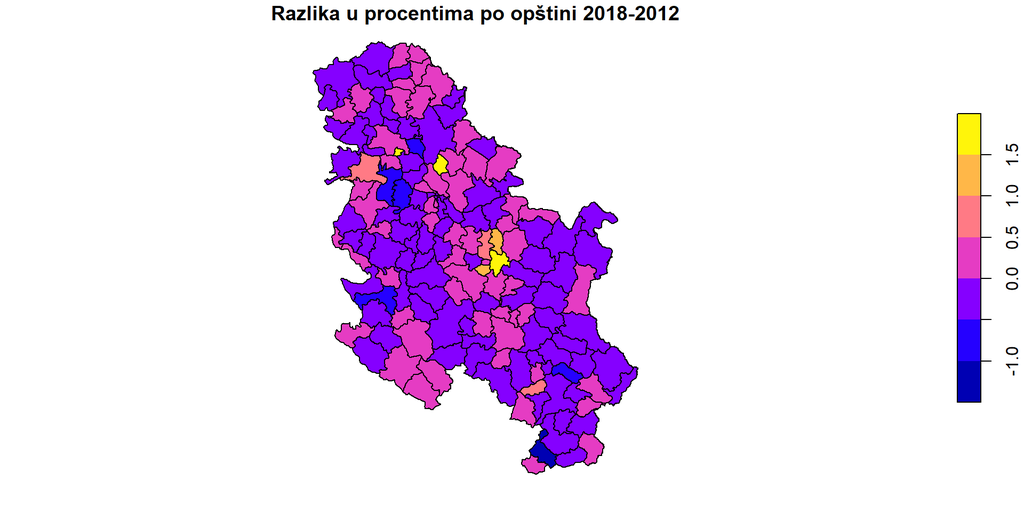

```r
plot(opst["razlika_18_12"], ,main = "Razlika u procentima po opštini 2018-2012")
```

## Površine šumskih klasa po svim opštinama `tidyverse`

```r
# Računanje ukupne površine šuma po opština
povrsine_sume <- opst_sume18 |>
  group_by(Name) |>
  summarise(Povrsina_Suma_km2 = sum(set_units(st_area(geom), "km2"))) # ... itd
# obratiti pažnju da su opštine bez šuma izbrisane i iz objekata povrsine sume
povrsine_sume
```

```
Simple feature collection with 154 features and 2 fields
Geometry type: GEOMETRY
Dimension:     XY
Bounding box:  xmin: 332131.6 ymin: 4676620 xmax: 660837.7 ymax: 5115967
Projected CRS: ETRS89 / UTM zone 34N
# A tibble: 154 × 3
   Name          Povrsina_Suma_km2                                          geom
   <chr>                    [km^2]                            <MULTIPOLYGON [m]>
 1 Ada                       0.930 (((433686 5069929, 433685.6 5069944, 433684.…
 2 Aleksandrovac           159.    (((482088.3 4804013, 481998.4 4804008, 48194…
 3 Aleksinac               253.    (((544943.9 4799164, 544851.3 4799204, 54476…
 4 Alibunar                 38.3   (((498928.5 4977394, 498908.6 4977493, 49877…
 5 Apatin                   37.2   (((338950.8 5048186, 338954.2 5048185, 33905…
 6 Aranđelovac             133.    (((455615 4893072, 455661.4 4893009, 455839.…
 7 Arilje                  195.    (((415733.9 4822842, 415481.8 4822807, 41516…
 8 Babušnica               299.    (((609147.2 4758497, 609032 4758591, 608833.…
 9 Bajina Bašta            352.    (((368410.3 4856571, 368437 4856573, 368503.…
10 Barajevo                 33.9   (((446794.2 4927603, 446809.7 4927650, 44680…
# ℹ 144 more rows
```